# Aplicacion de vacunas COVID19 en Argentina - NOMIVAC: 2020-2023

## 3.2 Análisis hipotéticos

En esta sección se presentan relaciones entre variables con el fin de explorar entre los resultados anteriores cuales se corresponden con algun tipo de explicacion proveniente de fenomenos culturales y sociales.

- Jovenes y la adherencia de los esquemas (estatico)
- Retomar los dias de la semana

### 3.2.1 `sexo`

### 3.2.2 `grupo_etario`

### 3.2.3 `condicion_aplicacion`

### 3.2.4 `jurisdiccion_aplicacion`

## 3.3 Creo nuevas variables que me sirvan para operar con la fecha

```r
# Obtener cantidad de personas por cantidad de dosis aplicadas y por sexo:
dosis_personas <- data_reg %>%
  group_by(id_persona) %>%
  filter(fecha_aplicacion == max(fecha_aplicacion)) %>%
  group_by(orden_dosis, sexo) %>%
  summarise(pob = n()) %>%
  arrange(desc(orden_dosis))
print(dosis_personas)
```

```
## # A tibble: 18 × 3
## # Groups:   orden_dosis [7]
##    orden_dosis sexo    pob
##          <dbl> <chr> <int>
##  1           7 F         7
##  2           7 M        10
##  3           6 F        21
##  4           6 M        21
##  5           5 F        29
##  6           5 M        21
##  7           4 F      1216
##  8           4 M      1066
##  9           4 S.I.      3
## 10           3 F      2327
## 11           3 M      1892
## 12           3 S.I.      7
## 13           2 F       676
## 14           2 M       639
## 15           2 S.I.      6
## 16           1 F       435
## 17           1 M       426
## 18           1 S.I.      3
```

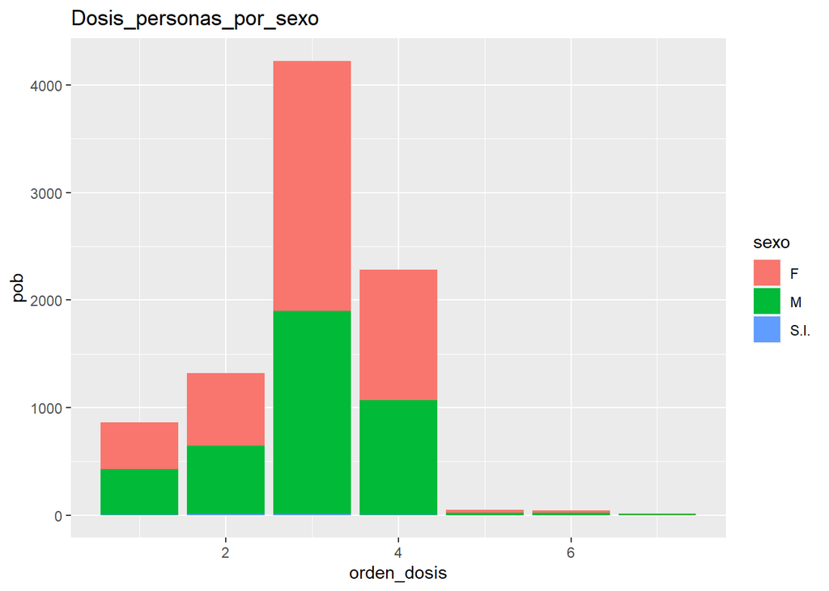

```r
dosis_personas %>%
  ggplot(aes(orden_dosis, pob, fill = sexo)) +
  geom_col() +
  labs(title = paste0("Dosis_personas_por_sexo"))
```

```r
ggsave(paste0("png/dosis_personas_","sexo", ".png"))
# Armar la tabla en formato wide
dosis_personas_w <- dosis_personas %>%
  pivot_wider(names_from = sexo,
              values_from = pob,
              values_fill = 0)
print(dosis_personas_w)
```

```
## # A tibble: 7 × 4
## # Groups:   orden_dosis [7]
##   orden_dosis     F     M  S.I.
##         <dbl> <int> <int> <int>
## 1           7     7    10     0
## 2           6    21    21     0
## 3           5    29    21     0
## 4           4  1216  1066     3
## 5           3  2327  1892     7
## 6           2   676   639     6
## 7           1   435   426     3
```

```r
# Armar una tabla como antes, solo para M y con prop
hombres_por_dosis <- data_reg %>%
  group_by(id_persona) %>%
  filter(fecha_aplicacion == max(fecha_aplicacion)) %>%
  filter(sexo == "M") %>%
  group_by(orden_dosis) %>%
  summarise(M_pob = n()) %>%
  mutate(M_nrel = M_pob/sum(M_pob) * 100,
         Freq_rel_acum_M = (cumsum(M_pob) / sum(M_pob) * 100)) %>%
  arrange((orden_dosis))
print(hombres_por_dosis)
```

```
## # A tibble: 7 × 4
##   orden_dosis M_pob M_nrel Freq_rel_acum_M
##         <dbl> <int>  <dbl>           <dbl>
## 1           1   426 10.5              10.5
## 2           2   639 15.7              26.1
## 3           3  1892 46.4              72.6
## 4           4  1066 26.2              98.7
## 5           5    21  0.515            99.2
## 6           6    21  0.515            99.8
## 7           7    10  0.245           100
```

```r
# Armar una tabla como antes, solo para F y con prop
mujeres_por_dosis <- data_reg %>%
  group_by(id_persona) %>%
  filter(fecha_aplicacion == max(fecha_aplicacion)) %>%
  filter(sexo == "F") %>%
  group_by(orden_dosis) %>%
  summarise(F_pob = n()) %>%
  mutate(F_nrel = F_pob/sum(F_pob) * 100,
         Freq_rel_acum_F = (cumsum(F_pob) / sum(F_pob) * 100)) %>%
  arrange((orden_dosis))
print(mujeres_por_dosis)
```

```
## # A tibble: 7 × 4
##   orden_dosis F_pob F_nrel Freq_rel_acum_F
##         <dbl> <int>  <dbl>           <dbl>
## 1           1   435  9.23             9.23
## 2           2   676 14.3             23.6
## 3           3  2327 49.4             73.0
## 4           4  1216 25.8             98.8
## 5           5    29  0.616           99.4
## 6           6    21  0.446           99.9
## 7           7     7  0.149          100
```

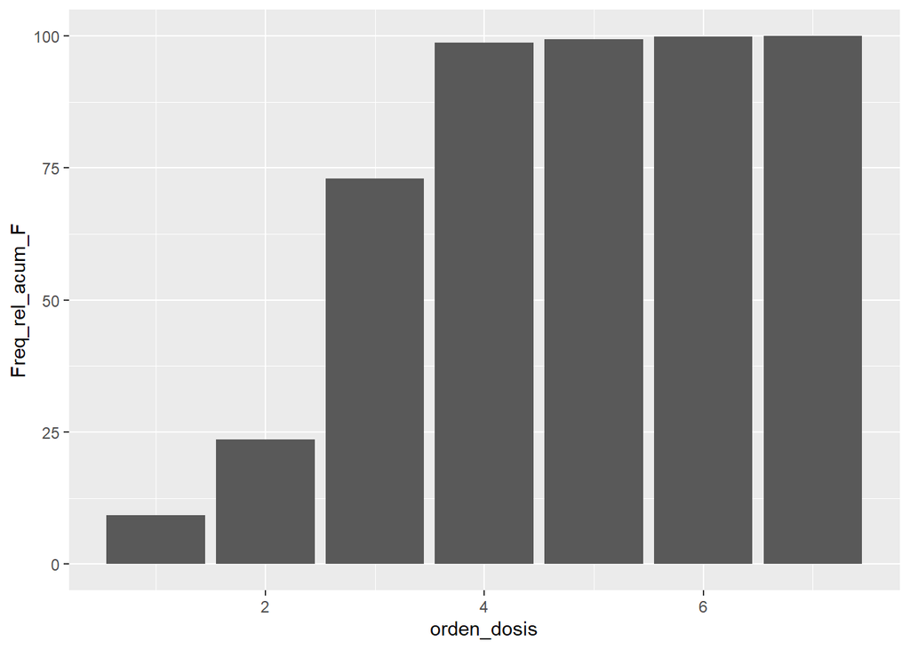

```r
mujeres_por_dosis %>%
  ggplot(aes(orden_dosis, Freq_rel_acum_F)) + geom_col()
```

```r
# Full outer join: combinacion externa es cuando algun codigo identificador no esta disponible en la otra base.
# En este caso debe agregarse el parametro all = TRUE para que aquellos sin coincidencia en el merge no se eliminen.
sexojoin <- merge(hombres_por_dosis, mujeres_por_dosis, by = "orden_dosis", all = TRUE)
sexojoin <- sexojoin %>%
  arrange((orden_dosis))

# Reemplazar los valores NA por ceros
#sexojoin <- sexojoin %>% mutate_all(~ifelse(is.na(.), 0, .))
#sexojoin <- replace_na(sexojoin, replace = 0)

print(dosis_personas)
```

```
## # A tibble: 18 × 3
## # Groups:   orden_dosis [7]
##    orden_dosis sexo    pob
##          <dbl> <chr> <int>
##  1           7 F         7
##  2           7 M        10
##  3           6 F        21
##  4           6 M        21
##  5           5 F        29
##  6           5 M        21
##  7           4 F      1216
##  8           4 M      1066
##  9           4 S.I.      3
## 10           3 F      2327
## 11           3 M      1892
## 12           3 S.I.      7
## 13           2 F       676
## 14           2 M       639
## 15           2 S.I.      6
## 16           1 F       435
## 17           1 M       426
## 18           1 S.I.      3
```

```r
print(dosis_personas_w)
```

```
## # A tibble: 7 × 4
## # Groups:   orden_dosis [7]
##   orden_dosis     F     M  S.I.
##         <dbl> <int> <int> <int>
## 1           7     7    10     0
## 2           6    21    21     0
## 3           5    29    21     0
## 4           4  1216  1066     3
## 5           3  2327  1892     7
## 6           2   676   639     6
## 7           1   435   426     3
```

```r
print(hombres_por_dosis)
```

```
## # A tibble: 7 × 4
##   orden_dosis M_pob M_nrel Freq_rel_acum_M
##         <dbl> <int>  <dbl>           <dbl>
## 1           1   426 10.5              10.5
## 2           2   639 15.7              26.1
## 3           3  1892 46.4              72.6
## 4           4  1066 26.2              98.7
## 5           5    21  0.515            99.2
## 6           6    21  0.515            99.8
## 7           7    10  0.245           100
```

```r
print(mujeres_por_dosis)
```

```
## # A tibble: 7 × 4
##   orden_dosis F_pob F_nrel Freq_rel_acum_F
##         <dbl> <int>  <dbl>           <dbl>
## 1           1   435  9.23             9.23
## 2           2   676 14.3             23.6
## 3           3  2327 49.4             73.0
## 4           4  1216 25.8             98.8
## 5           5    29  0.616           99.4
## 6           6    21  0.446           99.9
## 7           7     7  0.149          100
```

```r
print(sexojoin)
```

```
##   orden_dosis M_pob     M_nrel Freq_rel_acum_M F_pob     F_nrel Freq_rel_acum_F
## 1           1   426 10.4539877        10.45399   435  9.2337083        9.233708
## 2           2   639 15.6809816        26.13497   676 14.3493950       23.583103
## 3           3  1892 46.4294479        72.56442  2327 49.3950329       72.978136
## 4           4  1066 26.1595092        98.72393  1216 25.8119295       98.790066
## 5           5    21  0.5153374        99.23926    29  0.6155806       99.405646
## 6           6    21  0.5153374        99.75460    21  0.4457652       99.851412
## 7           7    10  0.2453988       100.00000     7  0.1485884      100.000000
```

```r
rm(hombres_por_dosis, mujeres_por_dosis)
```

# 4 Hipótesis

Finalmente, esta sección contiene al menos 3 hipótesis o preguntas que puedan ser respondidas a partir de los datos. Éstas tienen que ser más o menos interesantes y no cosas que se hayan respondido con la exploración anterior.

Traten de que sean hipótesis o preguntas que relacionen 2 o más variables. Por ejemplo, “¿Cuál es el mes con más turistas en una región?” no es una pregunta intersante, pero “Existe una relación entre la cantidad de visitas y la cantidad de hoteles en una región” es una hipótesis más jugosa que apunta a la relación entre varias variables y a un fenómeno subyacente que puede tener implicancia y aplicaciones.

Debido a la disponibilidad gradual de dosis de vacunas al comienzo de la pandemia resulta necesario establecer una priorización y ordenamiento de la poblacion objetivo a inmunizar en las primeras rondas con la finalidad de salvaguardar aquellos mas susceptibles, expuestos, vulnerables o de alto riesgo. Para maximizar el cuidado general de la poblacion se cree que mayores de edad, personas con comorbilidades y personal estrategico fueron los priorizados del sistema, teniendo en cuenta que el orden de priorizacion basal es evitar la muerte seguido de evitar enfermar con gravedad.

1. Por esta razón se indagará en las etapas tempranas de vacunacion la incidencia de la poblacion objetivo sobre el total y comparar esos valores con los registrados al finalizar la emergencia mundial cuando la vacuna alcanzo la suficiencia en disponibilidad irrestricta. -> Se indagará sobre las etapas tempranas de vacunacion si las mismas fueron dirigidas a quien se esperaría como poblacion diana bajo la premisa anterior, en qué proporciones y su evolucion.
2. Como segundo criterio ordenador de la estrategia de vacunacion se priorizo las personas que habitan grandes ciudades por la poca distancia que se mantiene y en condiciones de alta densidad demografica. Se puede analizar por departamentos provinciales.
3. Se cree que la poblacion priorizada obtuvo sus dosis de forma mas frecuente que otras poblaciones. Días de descanso entre dosis que tiene en promedio cada poblacion objetivo mediante la fecha de aplicacion de cada registro para cada persona. -> Para eso se calculará la cantidad de dias promedio que pasan entre una dosis y otra. dias_prom_vac1_vac2, dias_prom_vac2_vac3… y un total para dias_prom_vac1_vac99.
4. Se comenzó a flexibilizar la ASPO (AISLAMIENTO SOCIAL PREVENTIVO Y OBLIGATORIO) desde la gran disponibilidad de vacunas a partir del 2022. -> Veremos cuando se registraron picos de vacunacion que permitieron una mayor circulacion libre e irrestricta.
5. Se desea conocer alguna relacion que pueda observarse a traves de los registros sobre jurisdiccion de residencia y de aplicacion. Posiblemente existio una migracion de poblaciones debido al ASPO que puede observarse mediante este cruce o simplemente pueda obtenerse una “foto” de como las personas se mueven de su residencia hasta la aplicacion. Mediante datos espaciales disponibles en INDEC y datos abiertos se puede medir aproximadamente el desplazamiento entre ambos puntos.
6. Los mas jovenes registraron menor adherencia a los esquemas de vacunacion que los adultos para todo el periodo en que la disponibilidad es de vacunacion libre sin requisito de etapas. Se cree que los jovenes no confian en la nueva tecnologia de inmunizacion.

## 4.1 Otras exploraciones posibles

1. vac_inicia “vacunados con esquema iniciado”
2. vac_completa “vacunados con esquema completo”
3. group_by(sexo, grupo_etario)
4. group_by(sexo, grupo_etario, condicion_salud)

```r
#tabla cruce de migraciones residencia ~ lugar de aplicacion. A modo exploratorio.
jurisdicciones_cruce <- table(data_reg$jurisdiccion_residencia, data_reg$jurisdiccion_aplicacion)
jurisdicciones_cruce_id <- table(data_reg$jurisdiccion_residencia_id, data_reg$jurisdiccion_aplicacion_id)

#jurisdicciones_cruce
#jurisdicciones_cruce_id

rm(jurisdicciones_cruce, jurisdicciones_cruce_id)
```

Se observa que la gran mayoría de personas se aplica la vacuna en su lugar de residencia, salvo pocas excepciones. Es dificil de visualizar cuantas personas se vacunan fuera de su jurisdiccion, por ello a continuacion se presenta un gráfico.

```r
# Armar una tabla con la caracterizacion de la poblacion del registro respecto la cantidad de personas segun al lugar de residencia y lugar de la ultima aplicacion.

## Primero una tabla con la cantidad de residentes de cada jurisdiccion:
pob_resid <- data_reg %>%
  group_by(jurisdiccion_residencia) %>%
  summarise(n = n())
## Segundo una tabla con la cantidad de aplicaciones de cada jurisdiccion:
pob_aplic <- data_reg %>%
  group_by(jurisdiccion_aplicacion) %>%
  summarise(n = n())
## Tercero la union de ambas tablas con join_by ya que usan nombres diferentes de identificacion y sufijo porque ambos usan el mismo estadistico n.
jurisdicciones_poblacion <-
  full_join(pob_resid, pob_aplic, join_by(jurisdiccion_residencia == jurisdiccion_aplicacion), suffix = c("_residencia", "_aplicacion"))
## Cuarto aplico la diferencia entre residentes y vacunados.
jurisdicciones_poblacion <- jurisdicciones_poblacion %>%
  mutate(vac_extra = n_aplicacion - n_residencia) %>%
  arrange(jurisdiccion_residencia) %>%
  rename(jurisdiccion = jurisdiccion_residencia)

rm(pob_resid, pob_aplic)
```

```r
# detalle extra:

## cantidad de personas *residentes* de cada jurisdiccion que se aplican en *la misma* jurisdiccion.
jresidentes <- data_reg %>%
  filter(jurisdiccion_residencia == jurisdiccion_aplicacion) %>%
  group_by(jurisdiccion_residencia) %>%
  summarise(res_fix = n()) %>%
  arrange(jurisdiccion_residencia) %>%
  rename(jurisdiccion = jurisdiccion_residencia)

## cantidad de personas *aplicadas* en cada jurisdiccion que residen en otra jurisdiccion.
jnoresidentes <- data_reg %>%
  filter(jurisdiccion_residencia != jurisdiccion_aplicacion) %>%
  group_by(jurisdiccion_aplicacion) %>%
  summarise(nores_fix = n()) %>%
  arrange(jurisdiccion_aplicacion) %>%
  rename(jurisdiccion = jurisdiccion_aplicacion)

## cantidad de personas *residentes* de cada jurisdiccion que se aplican en *otra* jurisdiccion.
jno_residentes <- data_reg %>%
  filter(jurisdiccion_residencia != jurisdiccion_aplicacion) %>%
  group_by(jurisdiccion_residencia) %>%
  summarise(res_nofix = n()) %>%
  arrange(jurisdiccion_residencia) %>%
  rename(jurisdiccion = jurisdiccion_residencia)

#vacunados por jurisdiccion:
#jresidentes ## aplicados en la jurisdiccion de residencia, FIX = vacunados
#jnoresidentes ## aplicados en esta jurisdiccion que no es la de su residencia, FIX = vacunados
#jno_residentes ## aplicados en otra jurisdiccion que no es la de residencia, noFIX = no vacunados
```

```r
# extiendo el df para toda la informacion asociada a estas variables
jurisdicciones_poblacion <- full_join(jurisdicciones_poblacion, jresidentes, by = "jurisdiccion")
jurisdicciones_poblacion <- full_join(jurisdicciones_poblacion, jnoresidentes, by = "jurisdiccion")
jurisdicciones_poblacion <- full_join(jurisdicciones_poblacion, jno_residentes, by = "jurisdiccion")

# libero espacio
rm(jresidentes, jnoresidentes, jno_residentes)

# reordeno, mejor lectura
col_order <- c("jurisdiccion", "n_residencia", "res_fix", "res_nofix", "n_aplicacion", "nores_fix", "vac_extra")
jurisdicciones_poblacion <- jurisdicciones_poblacion %>%
  select(col_order)
# alternativa de reorden
#jurisdicciones_poblacion <- jurisdicciones_poblacion[, col_order]
```

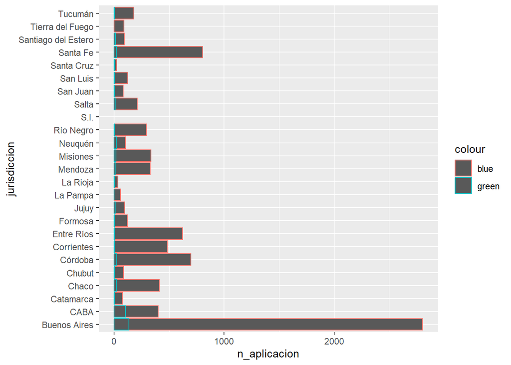

```r
# aplicaciones segun residencia de cada jurisdiccion.
ggplot(jurisdicciones_poblacion, aes(n_aplicacion, jurisdiccion)) +
  geom_col(aes(res_fix, jurisdiccion, color = "blue")) +
  geom_col(aes(nores_fix, jurisdiccion, color = "green"))
```

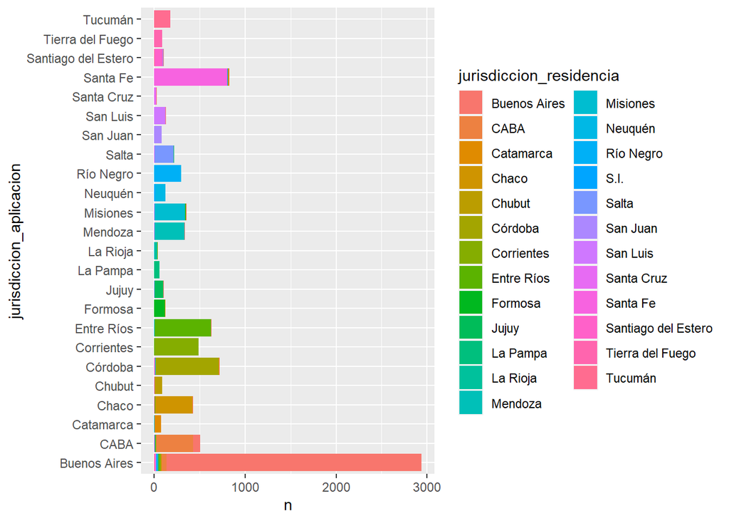

```r
data_reg %>%
  group_by(jurisdiccion_aplicacion, jurisdiccion_residencia) %>%
  summarise(n = n()) %>%
  arrange(desc(n)) %>%
  ggplot(aes(n, jurisdiccion_aplicacion, fill = jurisdiccion_residencia)) + geom_col()
```

```r
ggsave(paste0("png/jurisdicciones_","residencia_v_aplicacion1" ,".png"))
```

se puede observar que residentes de la provincia de Buenos Aires se aplicaron en otras jurisdcciones mas que otros ciudadanos.

Parece interesante, contrastar esta fuga de bonaerenses contra, cuantas otras personas se fugan de su jurisdiccion y donde tuvieron acogida.

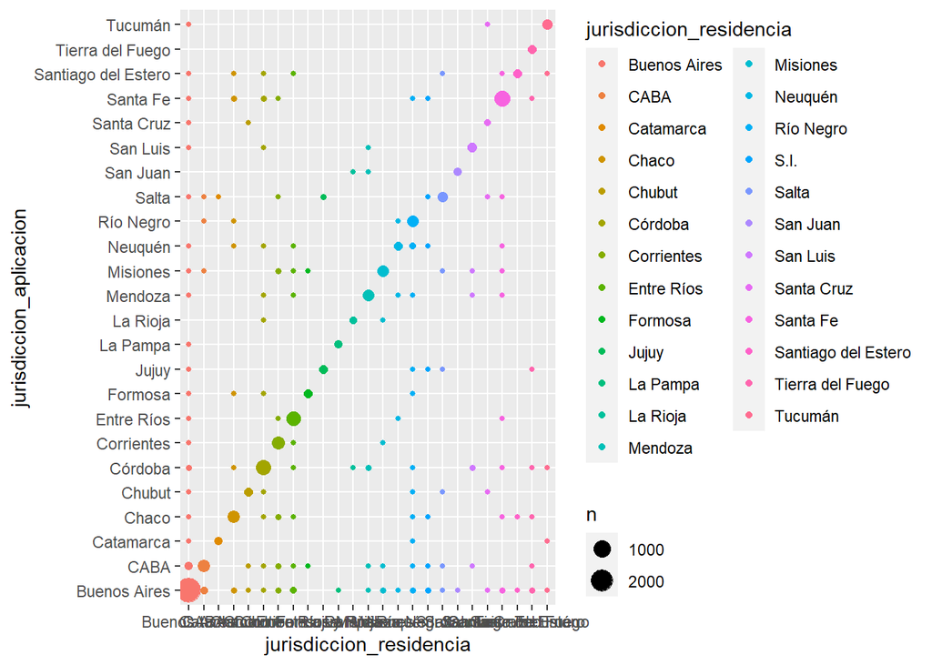

```r
data_reg %>%
  group_by(jurisdiccion_residencia, jurisdiccion_aplicacion) %>%
  summarise(n = n()) %>%
  mutate(prop = n/sum(n) * 100) %>%
  arrange(jurisdiccion_residencia) %>%
  ggplot(aes(jurisdiccion_residencia, jurisdiccion_aplicacion, size = n)) +
  geom_point(aes(color = jurisdiccion_residencia))
```

```r
# Guardo
ggsave(paste0("png/jurisdicciones_","residencia_v_aplicacion2" ,".png"))
```

```r
jovenes <- data_reg %>%
  mutate(grupo_etario_proxy = substr(grupo_etario, nchar(grupo_etario) - 2, nchar(grupo_etario)),
         jovenes = ifelse(grupo_etario_proxy < 30, "joven", "adulto")) %>%
  select(grupo_etario, grupo_etario_proxy, jovenes)

#table(data$sexo, data$grupo_etario)

#condicion_sexo <- table(data$condicion_aplicacion, data$grupo_etario)
#condicion_sexo <- round(prop.table(condicion_sexo) * 100, 2)
```